# Regressão Logística - Churn

## Bibliotecas

```python
import pandas as pd
import seaborn as sns
import matplotlib.pyplot as plt
import numpy as np
from sklearn.linear_model import LogisticRegression
from sklearn.model_selection import train_test_split
from sklearn.metrics import roc_auc_score, roc_curve, precision_score, recall_score, confusion_matrix, classification_report


sns.set_palette("Set2")
```

## Leitura dos dados

```python
df = pd.read_csv('Churn_Modelling.csv')
```

```python
df.head()
```

|  | RowNumber | CustomerId | Surname | CreditScore | Geography | Gender | Age | Tenure | Balance | NumOfProducts | HasCrCard | IsActiveMember | EstimatedSalary | Exited |
| --- | --- | --- | --- | --- | --- | --- | --- | --- | --- | --- | --- | --- | --- | --- |
| 0 | 1 | 15634602 | Hargrave | 619 | France | Female | 42 | 2 | 0.00 | 1 | 1 | 1 | 101348.88 | 1 |
| 1 | 2 | 15647311 | Hill | 608 | Spain | Female | 41 | 1 | 83807.86 | 1 | 0 | 1 | 112542.58 | 0 |
| 2 | 3 | 15619304 | Onio | 502 | France | Female | 42 | 8 | 159660.80 | 3 | 1 | 0 | 113931.57 | 1 |
| 3 | 4 | 15701354 | Boni | 699 | France | Female | 39 | 1 | 0.00 | 2 | 0 | 0 | 93826.63 | 0 |
| 4 | 5 | 15737888 | Mitchell | 850 | Spain | Female | 43 | 2 | 125510.82 | 1 | 1 | 1 | 79084.10 | 0 |

```python
len(df)
```

```
10000
```

```python
df.isnull().sum()
```

```
RowNumber          0
CustomerId         0
Surname            0
CreditScore        0
Geography          0
Gender             0
Age                0
Tenure             0
Balance            0
NumOfProducts      0
HasCrCard          0
IsActiveMember     0
EstimatedSalary    0
Exited             0
dtype: int64
```

```python
# Removendo colunas com dados pessoais dos clientes
df = df.drop(["RowNumber", "CustomerId", "Surname"], axis = 1)
```

## Análise inicial

### Proporção de clientes (saíram vs não saíram)

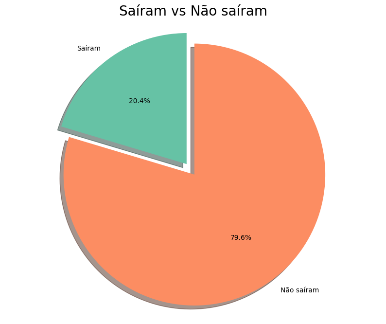

```python
labels = ['Saíram', 'Não saíram']
sizes = [df.Exited[df['Exited'] == 1].count(), df.Exited[df['Exited'] == 0].count()]
explode = (0, 0.1)

# Pie chart using matplotlib
fig1, ax1 = plt.subplots(figsize=(10, 8))
ax1.pie(sizes, explode=explode, labels=labels, autopct='%1.1f%%',
        shadow=True, startangle=90)
ax1.axis('equal')  # Equal aspect ratio ensures that pie is drawn as a circle.
plt.title("Saíram vs Não saíram", size=20)
plt.show()
```

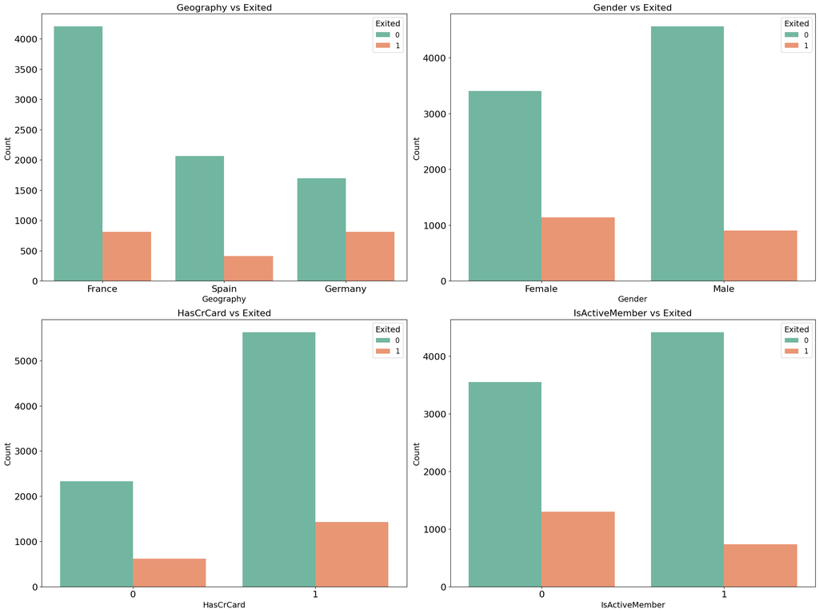

```python
fig, axarr = plt.subplots(2, 2, figsize=(20, 15))

features = ['Geography', 'Gender', 'HasCrCard', 'IsActiveMember']

for i, feature in enumerate(features):
    row, col = divmod(i, 2)
    sns.countplot(x=feature, hue='Exited', data=df, ax=axarr[row][col])
    axarr[row][col].set_title(f'{feature} vs Exited', fontsize=16)
    axarr[row][col].set_xlabel(feature, fontsize=14)
    axarr[row][col].set_ylabel('Count', fontsize=14)
    axarr[row][col].tick_params(axis='x', labelsize=16)
    axarr[row][col].tick_params(axis='y', labelsize=16)
    axarr[row][col].legend(title='Exited', fontsize=12, title_fontsize=14)


plt.tight_layout()
plt.show()
```

#### Observações

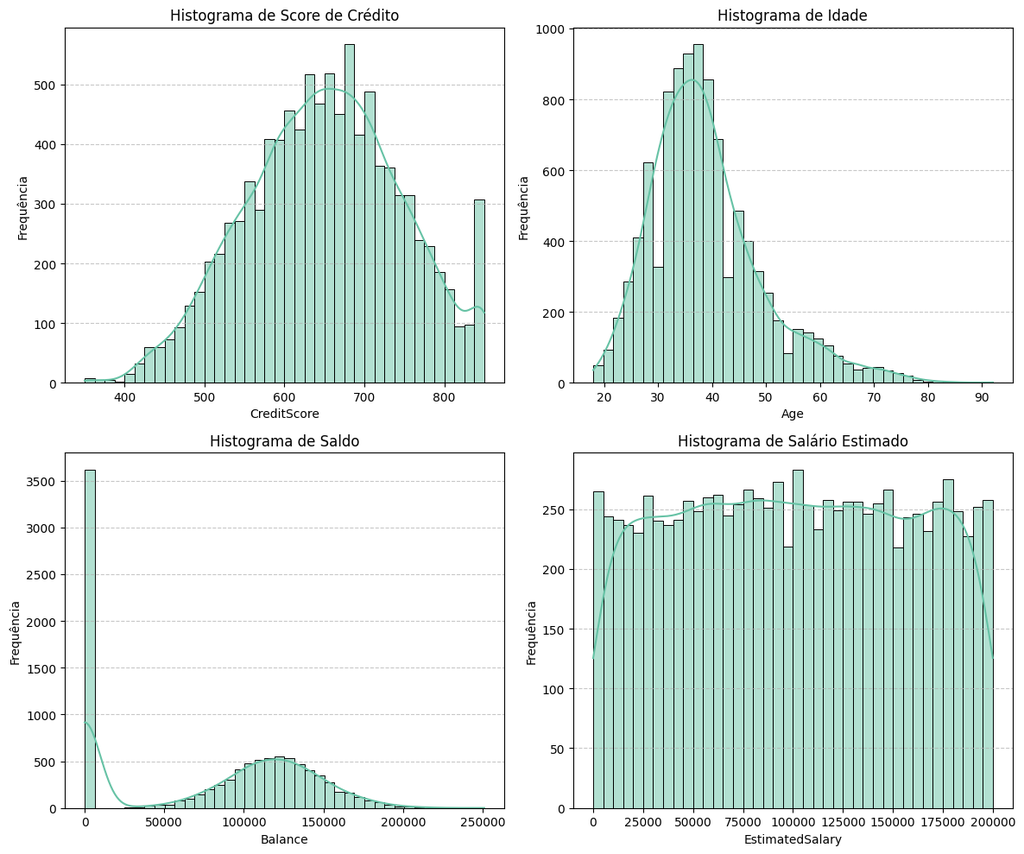

```python
import seaborn as sns
import matplotlib.pyplot as plt

columns = ['CreditScore', 'Age', 'Balance', 'EstimatedSalary']
titles = ['Histograma de Score de Crédito', 'Histograma de Idade',
          'Histograma de Saldo', 'Histograma de Salário Estimado']

fig, axes = plt.subplots(2, 2, figsize=(12, 10))

for i, ax in enumerate(axes.flat):
    sns.histplot(df[columns[i]], bins=40, kde=True, ax=ax)
    ax.set_title(titles[i])
    ax.set_xlabel(columns[i])
    ax.set_ylabel('Frequência')
    ax.grid(axis='y', linestyle='--', alpha=0.7)

plt.tight_layout()
plt.show()
```

#### Observações

- O score de crédito se concentra principalmente nos valores a partir de 600;
- A distribuição dos salários estimados é praticamente uniforme;
- Mais de um terço dos clientes tem o saldo da conta zerado;

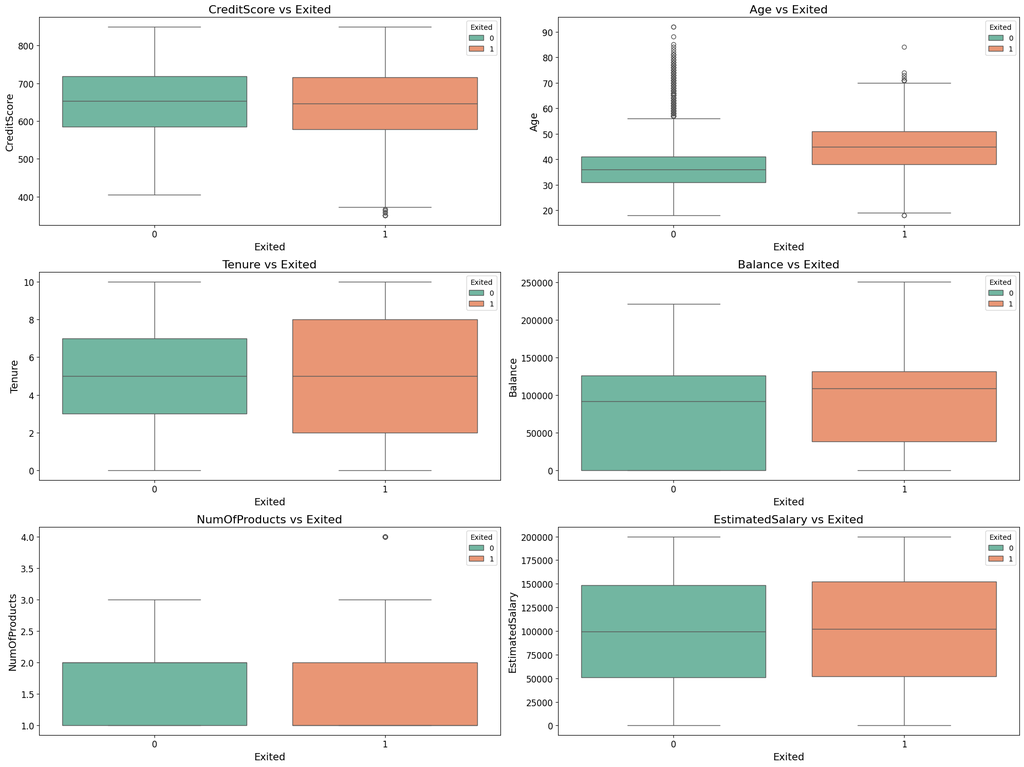

```python
fig, axarr = plt.subplots(3, 2, figsize=(20, 15))

features = ['CreditScore', 'Age', 'Tenure', 'Balance', 'NumOfProducts', 'EstimatedSalary']

for i, feature in enumerate(features):
    row, col = divmod(i, 2)  # Compute row and column index
    sns.boxplot(y=feature, x='Exited', hue='Exited', data=df, ax=axarr[row][col])
    axarr[row][col].set_title(f'{feature} vs Exited', fontsize=16)
    axarr[row][col].set_xlabel('Exited', fontsize=14)
    axarr[row][col].set_ylabel(feature, fontsize=14)
    axarr[row][col].tick_params(axis='both', labelsize=12)

plt.tight_layout()
plt.show()
```

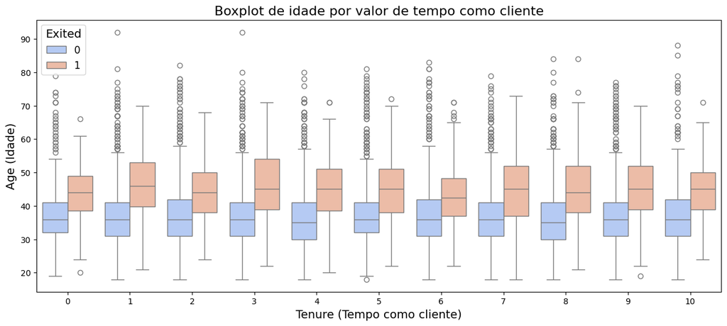

```python
plt.figure(figsize=(15, 6))

sns.boxplot(x='Tenure', y='Age', hue='Exited', data=df, palette='coolwarm')

plt.title('Boxplot de idade por valor de tempo como cliente', fontsize=16)
plt.xlabel('Tenure (Tempo como cliente)', fontsize=14)
plt.ylabel('Age (Idade)', fontsize=14)
plt.legend(title='Exited', fontsize=12, title_fontsize=14)
plt.show()
```

#### Observações

- Não há uma diferença significativa na distribuição do score de crédito, o número de produtos adquiridos e o salário entre os clientes que permaneceram e os que cancelaram o serviço.
- Clientes mais velhos cancelam mais do que os mais jovens, sugerindo uma possível diferença nas preferências de serviço entre as faixas etárias. O banco pode precisar revisar seu público-alvo ou ajustar a estratégia de retenção para os diferentes grupos de idade.
- Com relação ao tempo de relacionamento (tenure), há uma probabilidade maior dos clientes em ambas as extremidades – aqueles que passaram pouco tempo ou muito tempo no banco – de cancelar, em comparação com os clientes com tempo médio de relacionamento.
- O banco está perdendo clientes com saldos bancários significativos, o que pode impactar negativamente o capital disponível para empréstimos.

### Correlação das features

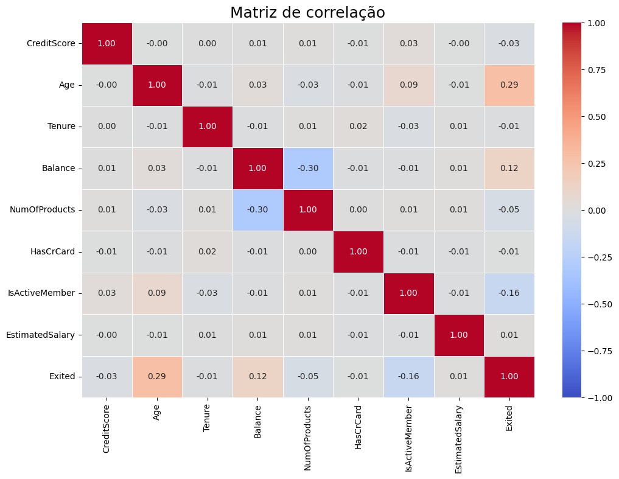

```python
numeric_df = df.select_dtypes(include=['number'])

corr_matrix = numeric_df.corr()
plt.figure(figsize=(12, 8))

sns.heatmap(corr_matrix, annot=True, cmap='coolwarm', fmt='.2f', vmin=-1, vmax=1, linewidths=0.5)

plt.title('Matriz de correlação', fontsize=18)
plt.show()
```

### Variáveis escolhidas

Baseado nas análises acima, as variáveis escolhidas são:

- "Age";
- "Balance";
- "Geography";
- "Gender";
- "NumOfProducts";
- "IsActiveMember".

```python
df_with_dummies = pd.get_dummies(df, columns=['Gender', 'Geography'], drop_first=True, dtype=int)
```

### Pressupostos da regressão logística

#### Linearidade entre as variáveis independentes e o logit

##### Variáveis contínuas

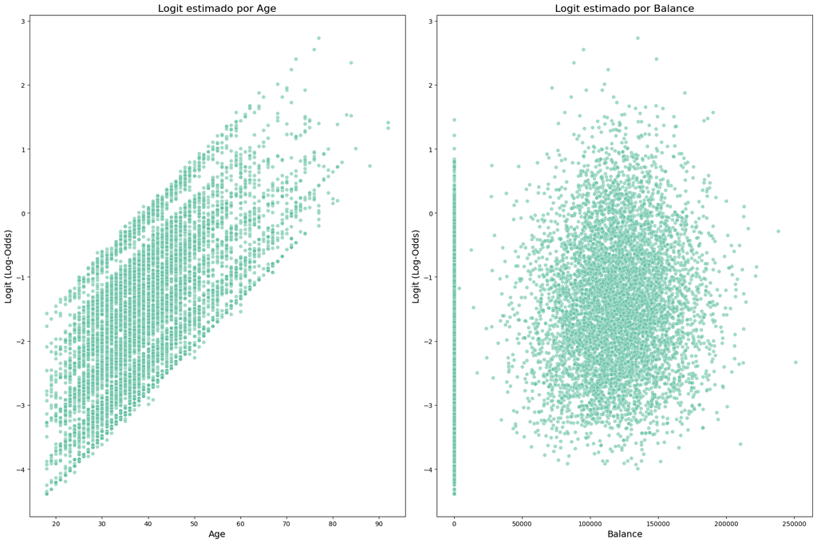

```python
X = df_with_dummies[['Age',  'Balance', 'IsActiveMember', 'NumOfProducts', 'Gender_Male', 'Geography_Spain', 'Geography_Germany']]
y = df['Exited']

log_reg = LogisticRegression(max_iter=1000)
log_reg.fit(X, y)

probs = log_reg.predict_proba(X)[:, 1]

logit = np.log(probs / (1 - probs))

fig, axarr = plt.subplots(1, 2, figsize=(18, 12))
features = ['Age',  'Balance']

for row, feature in enumerate(features):
    sns.scatterplot(x=df[feature], y=logit, alpha=0.6, ax=axarr[row])
    axarr[row].set_title(f'Logit estimado por {feature}', fontsize=16)
    axarr[row].set_xlabel(feature, fontsize=14)
    axarr[row].set_ylabel('Logit (Log-Odds)', fontsize=14)

plt.tight_layout()
plt.show()
```

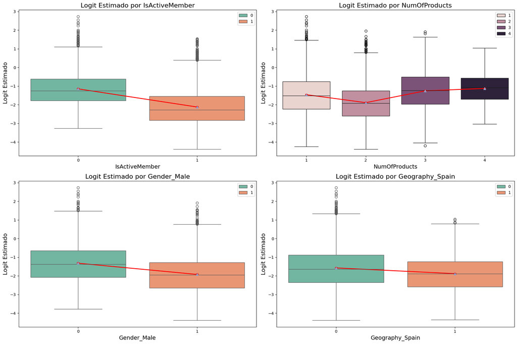

```python
X = df_with_dummies[['Age',  'Balance', 'IsActiveMember', 'NumOfProducts', 'Gender_Male', 'Geography_Spain', 'Geography_Germany']]
y = df_with_dummies['Exited']

log_reg = LogisticRegression(max_iter=1000)
log_reg.fit(X, y)

probs = log_reg.predict_proba(X)[:, 1]
logit = np.log(probs / (1 - probs))

df_with_dummies['logit'] = logit

variables = ['IsActiveMember', 'NumOfProducts', 'Gender_Male', 'Geography_Spain']

fig, axes = plt.subplots(2, 2, figsize=(18, 12))

for i, var in enumerate(variables):
    ax = axes[i // 2, i % 2]
    sns.boxplot(x=var, y='logit', data=df_with_dummies, hue=var, ax=ax, showmeans=True )
    means = df_with_dummies.groupby(var)['logit'].mean().sort_index()
    sns.pointplot(x=means.index, y=means.values, color='red', linestyle='-', marker='o', lw=2, ax=ax)

    ax.set_title(f'Logit Estimado por {var}', fontsize=16)
    ax.set_xlabel(var, fontsize=14)
    ax.set_ylabel('Logit Estimado', fontsize=14)


plt.tight_layout()
plt.show()
```

#### Ausência de Multicolinearidade

```python
from statsmodels.stats.outliers_influence import variance_inflation_factor


X = df_with_dummies[['Age',  'Balance','IsActiveMember', 'NumOfProducts', 'Gender_Male', 'Geography_Spain', 'Geography_Germany']].copy()
y = df_with_dummies['Exited'].copy()

X['Intercept'] = 1

vif = pd.DataFrame()
vif['Variável'] = X.columns
vif['VIF'] = [variance_inflation_factor(X.values, i) for i in range(X.shape[1])]
print(vif)
```

```
            Variável        VIF
0                Age   1.011818
1            Balance   1.335356
2     IsActiveMember   1.008815
3      NumOfProducts   1.121672
4        Gender_Male   1.002853
5    Geography_Spain   1.124437
6  Geography_Germany   1.339372
7          Intercept  29.229363
```

##### Balanceamento da variável dependente

```python
print(df['Exited'].value_counts(normalize=True) * 100)
```

```
Exited
0    79.63
1    20.37
Name: proportion, dtype: float64
```

#### Conclusões

##### Linearidade entre as variáveis independentes e o logit

Para as variáveis contínuas, foi feito o teste de comparação entre os valores preditos e o logit das probabilidades dadas pelo modelo para cada amostra. O logit é dado por:

$\Large{\displaystyle \operatorname {logit} p=\sigma ^{-1}(p)=\ln {\frac {p}{1-p}}\quad {\text{para}}\quad p\in (0,1).}$

A variável "Balance" não apresentou relação linear, então será descartada.

Para as variáveis categóricas, a verificação de linearidade é feita observando se o logit estimado muda consistentemente de uma categoria para outra [4].

Para "NumOfProducts", não há uma relação linear considerando os valores médios para cada categoria. Dessa forma, essa variável vai ser removida também.

##### Multicolinearidade

É possível checar o pressuposto de multicolinearidade (dependência linear entre variáveis independentes) por meio do cálculo do VIF (Variance Inflation Factor) para cada variável independente. Um valor superior a 5 indica multicolinearidade moderada e um valor acima de 10, alta.

Ao fazer o teste para as variáveis escolhidas, há apenas valores abaixo de 2, indicando que não há multicolinearidade.

##### Balanceamento da variável dependente

Por definição, dados desequilibrados são considerados pela literatura e pela maioria dos profissionais como os dados em que o número de observações da classe majoritária é duas vezes maior que o da classe minoritária [1].

No caso do dado acima, clientes que não saíram representam quase 80% do dado, ou seja, deve haver um balanceamento antes de treinar o modelo de regressão logística.

Há algumas formas de realizar isso:

- Por meio de amostragem balanceada:
  - Oversampling da classe minoritária com a técnica SMOTE.
  - Undersampling da classe majoritária.
- Por atribuição de pesos maiores à classe minoritária ao ajustar o modelo.

A terceira opção será utilizada, pois pode ser facilmente aplicada via o parâmetro *class_weight* da classe *LogisticRegression* do scikit-learn [2].

##### Referências

- [1] - [He H. and Ma Y., Imbalanced Learning: Foundations, Algorithms, and Applications, John Wiley & Sons, Hoboken, 2013](https://books.google.com.br/books?hl=pt-BR&lr=&id=CVHx-Gp9jzUC&oi=fnd&pg=PT9&ots=2jNnGoAp6m&sig=OCseE7jvj6d6keMNCAkGkpSpXa4&redir_esc=y#v=onepage&q=twice&f=false)
- [2] - [LogisticRegression - scikit-learn](https://scikit-learn.org/stable/modules/generated/sklearn.linear_model.LogisticRegression.html)
- [3] - [Check for multicollinearity of model terms](https://easystats.github.io/performance/reference/check_collinearity.html)
- [4] - [Introduction to Regression Methods for Public Health Using R](https://www.bookdown.org/rwnahhas/RMPH/mlr-linearity.html)

### Modelo com pressupostos validados

```python
df_with_dummies = pd.get_dummies(df, columns=['Gender', 'Geography'], drop_first=True, dtype=int)

X = df_with_dummies[['Age', 'IsActiveMember', 'Gender_Male', 'Geography_Spain', 'Geography_Germany']].copy()

y = df_with_dummies['Exited']

X_train, X_test, y_train, y_test = train_test_split(X, y, test_size=0.2, random_state=42)

log_reg = LogisticRegression(max_iter=2000, class_weight='balanced')
log_reg.fit(X_train, y_train)
```

```
LogisticRegression(class_weight='balanced', max_iter=2000)
```

```
AUC: 0.7777
```

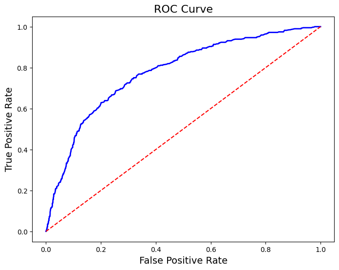

```
Precisão: 0.3750
Sensitividade (Recall): 0.7252
Especificidade: 0.7044
```

```python
y_pred_proba = log_reg.predict_proba(X_test)[:, 1]
y_pred = log_reg.predict(X_test)

auc = roc_auc_score(y_test, y_pred_proba)
print(f'AUC: {auc:.4f}')

fpr, tpr, thresholds = roc_curve(y_test, y_pred_proba)
plt.figure(figsize=(8, 6))
plt.plot(fpr, tpr, color='blue', lw=2)
plt.plot([0, 1], [0, 1], color='red', linestyle='--')  # Diagonal line
plt.xlabel('False Positive Rate', fontsize=14)
plt.ylabel('True Positive Rate', fontsize=14)
plt.title('ROC Curve', fontsize=16)
plt.show()

precision = precision_score(y_test, y_pred)
sensitivity = recall_score(y_test, y_pred)
cm = confusion_matrix(y_test, y_pred)

tn, fp, fn, tp = cm.ravel()
specificity = tn / (tn + fp)

print(f'Precisão: {precision:.4f}')
print(f'Sensitividade (Recall): {sensitivity:.4f}')
print(f'Especificidade: {specificity:.4f}')
```

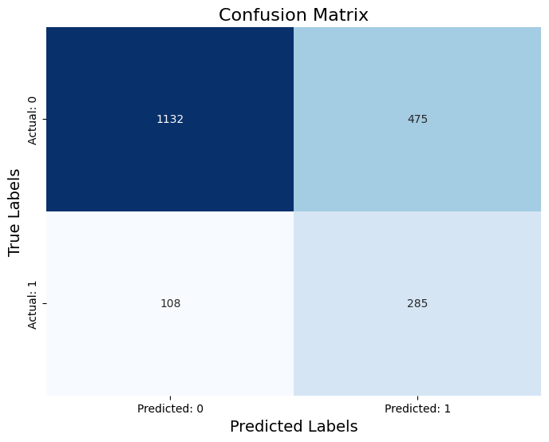

```python
plt.figure(figsize=(8, 6))
sns.heatmap(cm, annot=True, fmt='d', cmap='Blues', cbar=False, xticklabels=['Predicted: 0', 'Predicted: 1'], yticklabels=['Actual: 0', 'Actual: 1'])
plt.title('Confusion Matrix', fontsize=16)
plt.xlabel('Predicted Labels', fontsize=14)
plt.ylabel('True Labels', fontsize=14)
plt.show()
```

```python
report = classification_report(y_test, y_pred)
print("Classification Report:\n", report)
```

```
Classification Report:
               precision    recall  f1-score   support

           0       0.91      0.70      0.80      1607
           1       0.38      0.73      0.49       393

    accuracy                           0.71      2000
   macro avg       0.64      0.71      0.64      2000
weighted avg       0.81      0.71      0.74      2000
```

#### Avaliação das métricas e conclusões

No caso deste problema, o ideal é um modelo com uma performance maior para a previsão de saída de clientes. Isso significa que, entre várias opções de modelos, é preferível um com menos falsos negativos (e consequemente maior recall) para a classe 1 (clientes que saem).

É importante também tentar manter a precisão alta para classe 1, evitando desperdício de recursos do banco em manter clientes que não irão apresentar *churn*, isto é, um número alto de falsos positivos para a classe 1 também não é desejado.

##### Precisão

A precisão indica a proporção de previsões positivas corretas em relação ao total de previsões positivas feitas. Ou seja, de todos os casos que o modelo previu como "positivo" (classe 1), 37,5% estavam realmente corretos.

Isso sugere que o modelo tem uma taxa relativamente alta de falsos positivos, ou seja, ele está errando ao prever que um cliente sairá do banco quando, na verdade, não sairá.

##### Sensitividade (Recall)

A sensitividade (também chamada de recall ou taxa de verdadeiro positivo) mede a capacidade do modelo de identificar corretamente os positivos reais. Ou seja, de todos os clientes que realmente saíram do banco (classe 1), 72,52% foram corretamente identificados pelo modelo.

Isso indica um bom recall, ou seja, o modelo tem um bom desempenho em identificar os clientes que realmente saíram, o que é útil, pois o interesse maior está em prever a saída de clientes do banco.

##### Especificidade

A especificidade (ou taxa de verdadeiro negativo) mede a capacidade do modelo de identificar corretamente os negativos reais. Ou seja, de todos os clientes que não saíram do banco (classe 0), 70,44% foram corretamente identificados.

Nessa caso, o modelo também tem um bom desempenho em identificar corretamente os clientes que não saíram do banco.

##### AUC (Área sob a Curva ROC)

A AUC (Área sob a Curva ROC) é uma métrica que avalia a capacidade do modelo de distinguir entre as classes. A AUC varia de 0 a 1, sendo que valores mais altos indicam que o modelo tem uma boa capacidade discriminatória.

Com uma AUC de 0.7777, tem-se um indicativo que o modelo tem uma boa capacidade de discriminar entre as classes 0 e 1, ou seja, ele consegue diferenciar entre clientes que saem e os que não saem do banco.

##### Matriz de confusão

**Classe 0 (Clientes que não saem)**

**Classe 1 (Clientes que saem)**

Precisão (0.38): Para os clientes que saem, o modelo tem uma precisão de 38%. Ou seja, quando o modelo prevê que um cliente sairá, ele está certo em 38% dos casos. Recall (0.73): O modelo identifica corretamente 73% dos clientes que realmente saem. F1-Score (0.49): Indica que há um desequilíbrio entre precisão e recall para esta classe, com o recall sendo bem maior que a precisão.

**Médias**

Acurácia (0.71): O modelo tem uma acurácia geral de 71%, ou seja, ele acertou 71% das previsões no conjunto de dados.

Weighted Avg (0.81 (precisão), 0.71 (recall), 0.74 (F1-Score)): A média ponderada leva em conta o desequilíbrio entre as classes (mais amostras da classe 0), e o modelo tem um desempenho melhor na precisão, mas ainda mostra uma boa média no recall.

**Interpretação e Considerações**

A alta sensitividade (recall) para a classe 1 (73%) é boa, pois significa que o modelo está identificando uma boa parte dos clientes que saem do banco, mas a baixa precisão para a classe 1 (38%) sugere que o modelo também está cometendo muitos falsos positivos, ou seja, ele classifica incorretamente muitos clientes como prováveis de sair quando eles, na verdade, não saem.

A AUC de 0.7777 é razoavelmente boa, indicando que o modelo tem uma capacidade aceitável de distinguir entre as classes 0 e 1.

#### Interpretação dos coeficientes

```python
coefficients = log_reg.coef_[0]

coef_df = pd.DataFrame({
    'Variável': X_train.columns,
    'Coeficiente': coefficients,
    'Impacto': np.exp(coefficients)
})

coef_df = coef_df.sort_values(by='Impacto', ascending=False)

print(coef_df)
```

```
            Variável  Coeficiente   Impacto
4  Geography_Germany     0.918062  2.504431
3    Geography_Spain     0.106197  1.112041
0                Age     0.077213  1.080272
2        Gender_Male    -0.534258  0.586104
1     IsActiveMember    -0.921753  0.397821
```

##### Conclusões

O modelo de regressão logística, que mapeia um valor para um intervalo entre 0 e 1 (probabilidade de algum evento), é dado por:

$\Large{\displaystyle p (x) = \sigma (t)={\frac {e^{t}}{e^{t}+1}}={\frac {1}{1+e^{-t}}}}$

onde:

$\Large{\displaystyle t=\beta _{0}+\beta _{1}x + ... + \beta_nx_n}$

O inverso da função de regressão logística é chamada de logit e é dado por:

$\Large{\displaystyle g(p(x))=\sigma ^{-1}(p(x))=\operatorname {logit} p(x)=\ln \left({\frac {p(x)}{1-p(x)}}\right)=\beta _{0}+\beta _{1}x + ... + \beta_nx_n}$

Por meio dessa fórmula, é possível estimar como os coeficientes $\beta_i$ afetam a probabilidade de um evento.

Nesse caso, para cada unidade de aumento (ou diminuição) em um coeficiente (mantendo o restante inalterado), tem-se uma unidade de aumento (ou diminuição) no logit.

Além disso, aplicando a exponenciação aos coeficientes $exp(\beta_i)$ (batizado aqui de "impacto"), é possível descobrir como as odds de um evento mudam à medida que o coeficiente associado muda.

A interpretação do impacto é mais intuitiva. Por exemplo, "Age" tem um coeficiente de 0.077 e um impacto de aproximadamente 1.08, indicando que para cada aumento unitário na idade, a chance de um cliente sair do banco aumenta em 8%.